# Millennium Demo Queries

In this notebook we show how the demo queries from http://gavo.mpa-garching.mpg.de/Millennium translate to the SciServer/CasJobs interface.

## Schema documentation

The databases of the Millennium database can be accessed by joining the "Cosmology" science domain in SciServer.  
TBD document how  
Once when has joined this domain, in CasJobs one can find some 15 new databases beoyond the public SDSS databases. For example in the Query page "context' drop downm one now see databases like MPAHaloTrees, millimil, Guo2010a etc.  
(Note, one may need to refresh the CasJobs web page after joining the science domain).

The contents of these databases is documented at the 'Schema Browser' tab. For most (but not yet all) tables once can listthe columns with their name, datatype, unit and description.  
For a more comprehensive (though not more complete) documentation we refer to the original pages at http://gavo.mpa-garching.mpg.de/Millennium/Help/publicdbs.

```python
import SciServer.CasJobs as cj
import matplotlib.pyplot as plt
from mpl_toolkits.mplot3d import Axes3D
import numpy as np
import warnings
warnings.filterwarnings('ignore')
```

## H1

Find halos at a given redshift (snapnum) within a certain part of the simulation volume (X,Y,Z)

```python
sql="""
select *
  from MPAHalo
 where snapnum=50
   and np between 100 and 1000
   and x between 10 and 30
   and y between 10 and 30
   and z between 10 and 30
"""
df=cj.executeQuery(sql,"millimil")
df.head()
```

|  | haloID | subHaloID | lastProgenitorId | treeId | snapNum | redshift | firstProgenitorId | nextProgenitorId | descendantId | firstHaloInFOFgroupId | ... | velDisp | vMax | spinX | spinY | spinZ | mostBoundID | fileNr | subhaloIndex | halfmassRadius | random |
| --- | --- | --- | --- | --- | --- | --- | --- | --- | --- | --- | --- | --- | --- | --- | --- | --- | --- | --- | --- | --- | --- |
| 0 | 627000013 | 50000000001574 | 627000040 | 627000000 | 50 | 0.407899 | 627000014 | -1 | 627000012 | 627000013 | ... | 41.90405 | 77.27962 | -0.476765 | -0.272578 | -0.424508 | 1403906 | 0 | 1574 | 0.034117 | 767 |
| 1 | 759000013 | 50000000001546 | 759000041 | 759000000 | 50 | 0.407899 | 759000014 | -1 | 759000012 | 759000013 | ... | 43.20163 | 82.75902 | -0.168356 | -0.054436 | 0.135190 | 1773631 | 0 | 1546 | 0.028277 | 25 |
| 2 | 805000013 | 50000000001575 | 805000043 | 805000000 | 50 | 0.407899 | 805000014 | -1 | 805000012 | 805000013 | ... | 46.15208 | 93.90165 | -0.128143 | 0.001016 | -0.048002 | 1844721 | 0 | 1575 | 0.026715 | 533 |
| 3 | 406000013 | 50000000001514 | 406000040 | 406000000 | 50 | 0.407899 | 406000014 | -1 | 406000012 | 406000013 | ... | 44.78889 | 95.29464 | -0.257634 | -0.116733 | 0.124440 | 1882182 | 0 | 1514 | 0.024913 | 366 |
| 4 | 489000013 | 50000000001544 | 489000036 | 489000000 | 50 | 0.407899 | 489000014 | -1 | 489000012 | 489000013 | ... | 42.10012 | 82.42934 | 0.075781 | 0.203807 | -0.101628 | 1729710 | 0 | 1544 | 0.029592 | 608 |

5 rows × 36 columns

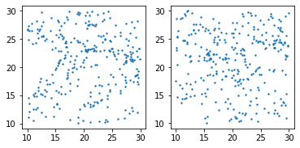

```python
fig,(ax1,ax2)= plt.subplots(1,2)
ax1.scatter(df.x,df.y,s=2)
ax1.set_aspect('equal')
ax2.scatter(df.x,df.z,s=2)
ax2.set_aspect('equal');
```

## H2

Find the whole progenitor tree, in depth-first order, of a halo identified by its haloId

```python
sql="""
select PROG.*
  from millimil..MPAHalo PROG,
       millimil..MPAHalo DES
 where DES.haloId = 1
   and PROG.haloId between DES.haloId and DES.lastprogenitorId
"""
tree=cj.executeQuery(sql,"millimil")
tree.head()
```

|  | haloID | subHaloID | lastProgenitorId | treeId | snapNum | redshift | firstProgenitorId | nextProgenitorId | descendantId | firstHaloInFOFgroupId | ... | velDisp | vMax | spinX | spinY | spinZ | mostBoundID | fileNr | subhaloIndex | halfmassRadius | random |
| --- | --- | --- | --- | --- | --- | --- | --- | --- | --- | --- | --- | --- | --- | --- | --- | --- | --- | --- | --- | --- | --- |
| 0 | 1 | 62000000000000 | 2444 | 0 | 62 | 0.019933 | 2 | 2445 | 0 | 1 | ... | 337.7839 | 582.9607 | 10.650140 | 13.18693 | 0.446840 | 464326 | 0 | 0 | 0.289785 | 315 |
| 1 | 2 | 61000000000000 | 2294 | 0 | 61 | 0.041403 | 3 | 2295 | 1 | 2 | ... | 333.0153 | 578.8763 | 9.782666 | 12.71298 | 0.525455 | 464326 | 0 | 0 | 0.289695 | 869 |
| 2 | 3 | 60000000000000 | 2291 | 0 | 60 | 0.064493 | 4 | 2292 | 2 | 3 | ... | 329.0703 | 572.9600 | 9.658756 | 12.94137 | 0.260007 | 450539 | 0 | 0 | 0.291491 | 331 |
| 3 | 4 | 59000000000000 | 2222 | 0 | 59 | 0.089288 | 5 | 2223 | 3 | 4 | ... | 327.8727 | 568.7360 | 7.978456 | 15.25529 | 1.618120 | 464326 | 0 | 0 | 0.293327 | 696 |
| 4 | 5 | 58000000000000 | 2222 | 0 | 58 | 0.115883 | 6 | -1 | 4 | 5 | ... | 327.0959 | 564.9458 | 7.154714 | 15.30042 | 2.410639 | 469547 | 0 | 0 | 0.294591 | 49 |

5 rows × 36 columns

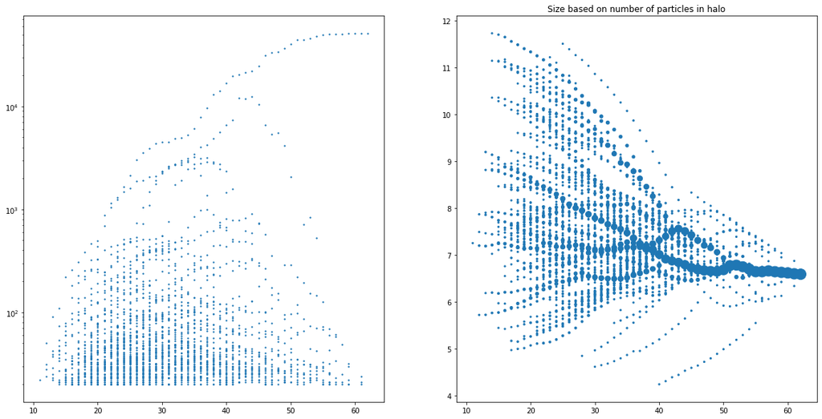

```python
fig,(ax1,ax2)= plt.subplots(1,2,figsize=(20,10))
ax1.scatter(tree.snapNum,tree.np,s=2);
ax1.set_yscale('log');
ax2.scatter(tree.snapNum,tree.x,s=np.sqrt(tree.np));
ax2.set_title("Size based on number of particles in halo");
```

## H3

```python
sql="""
select DES.haloId as descendant_id,
       DES.np as descendant_mass,
       PROG.haloid,prog.x,prog.y,prog.z,prog.np
  from millimil..MPAHalo DES,
       millimil..MPAHalo PROG
 where DES.snapnum = 63
   and DES.np > 10000
   and PROG.haloId between DES.haloId and DES.lastprogenitorId
   and PROG.snapnum = 40
   and PROG.np > 100
 order by DES.np desc, PROG.np desc
"""
df=cj.executeQuery(sql,"millimil")
print(len(df),"halos")
df.head()
```

```
772 halos
```

|  | descendant_id | descendant_mass | haloid | x | y | z | np |
| --- | --- | --- | --- | --- | --- | --- | --- |
| 0 | 3000042000000 | 137272 | 3000042000023 | 45.50401 | 12.48208 | 12.23454 | 52552 |
| 1 | 3000042000000 | 137272 | 3000042003027 | 42.79364 | 14.81862 | 11.28522 | 12985 |
| 2 | 3000042000000 | 137272 | 3000042001464 | 44.32127 | 12.46924 | 11.78894 | 4811 |
| 3 | 3000042000000 | 137272 | 3000042005052 | 44.05122 | 12.54817 | 11.87539 | 1243 |
| 4 | 3000042000000 | 137272 | 3000042004833 | 45.49595 | 12.73762 | 12.12408 | 808 |

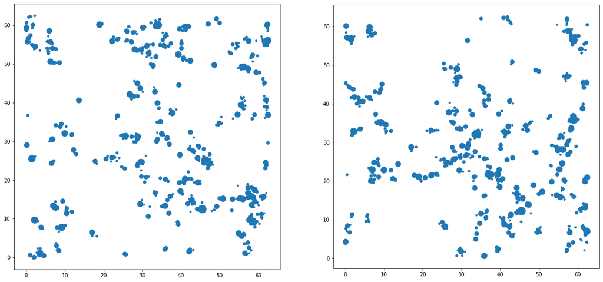

```python
fig,(ax1,ax2)= plt.subplots(1,2,figsize=(20,10))
ax1.scatter(df.x,df.y,s=np.sqrt(df.np))
ax1.set_aspect('equal')
ax2.scatter(df.x,df.z,s=np.sqrt(df.np))
ax2.set_aspect('equal');
```

## H4

Find all the halos of mass ≥ 1000 that have just had a major merger, defined by having at least two progenitors of mass ≥ 0.2*descendant mass.

```python
sql="""
select D.haloId,
       D.snapnum,
       D.np as d_np,
       p1.haloid as p1_id,
       P1.np as p1_np,
       p2.haloid as p2_id,
       P2.np as p2_np
  from millimil..MPAHalo P1,
       millimil..MPAHalo P2,
       millimil..MPAHalo D
 where P1.SNAPNUM=P2.SNAPNUM
   and P1.haloId < P2.haloId
   and P1.descendantId = D.haloId
   and P2.descendantId = D.haloId
   and P1.np >= .2*D.np
   and P2.np >= .2*D.np
   and D.np > 1000
"""
df=cj.executeQuery(sql,"millimil")
print(len(df),"major mergers")
df.head()
```

```
39 major mergers
```

|  | haloId | snapnum | d_np | p1_id | p1_np | p2_id | p2_np |
| --- | --- | --- | --- | --- | --- | --- | --- |
| 0 | 6000069000025 | 38 | 1211 | 6000069000026 | 519 | 6000069000072 | 295 |
| 1 | 1000031000024 | 39 | 3603 | 1000031000025 | 995 | 1000031000118 | 2375 |
| 2 | 926000048 | 28 | 1406 | 926000049 | 306 | 926000089 | 730 |
| 3 | 19000000 | 63 | 6698 | 19000001 | 4006 | 19000365 | 2473 |
| 4 | 7000057001683 | 57 | 1171 | 7000057001684 | 763 | 7000057001690 | 279 |

NB it is important to note that the mass of a satellite subhalo generally reduces for some time before it merges with the central halo. Hence the mass at thsnapshot just before merging is generally not an accurate representation of its original mass. This affects the definition of what constitutes a major merger.

## H5

Find the mass function of halos at z=0 using logarithmic intervals.

```python
sql="""
 select power(10, .1*(.5+floor(log10(np)/.1))) as mass,
        count(*) as num
   from millimil..MPAHalo
  where snapnum=63
 group by power(10, .1*(.5+floor(log10(np)/.1)))
 order by mass
"""
mf=cj.executeQuery(sql,"millimil")
mf.head()
```

|  | mass | num |
| --- | --- | --- |
| 0 | 22 | 7605 |
| 1 | 28 | 4887 |
| 2 | 35 | 4282 |
| 3 | 44 | 3900 |
| 4 | 56 | 2992 |

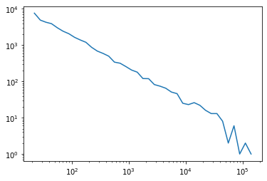

```python
plt.plot(mf.mass, mf.num)
plt.xscale('log')
plt.yscale('log');
```

## HF1

Find all halos residing in background overdensities between 2 and 3, at Gaussian smoothing radius 5 Mpc/h.

```python
sql="""
 select h.*
  from millimil..MPAHalo h,
       millimil..MMField f
 where f.g5 between 2 and 3
   and f.snapnum=63
   and f.snapnum = h.snapnum
   and f.phkey = h.phkey
   """
mf_3_5=cj.executeQuery(sql,"millimil")
mf_3_5.head()
```

|  | haloID | subHaloID | lastProgenitorId | treeId | snapNum | redshift | firstProgenitorId | nextProgenitorId | descendantId | firstHaloInFOFgroupId | ... | velDisp | vMax | spinX | spinY | spinZ | mostBoundID | fileNr | subhaloIndex | halfmassRadius | random |
| --- | --- | --- | --- | --- | --- | --- | --- | --- | --- | --- | --- | --- | --- | --- | --- | --- | --- | --- | --- | --- | --- |
| 0 | 2001810000046 | 63000300000353 | 2001810002091 | 2001810000000 | 63 | 0 | 2001810000047 | -1 | -1 | 2001810000046 | ... | 284.97580 | 501.77950 | 4.182136 | 7.270389 | -2.233520 | 5061646 | 3 | 353 | 0.249291 | 24 |
| 1 | 2001810002092 | 63000300000357 | 2001810002149 | 2001810000000 | 63 | 0 | 2001810002093 | -1 | -1 | 2001810000046 | ... | 67.20808 | 118.72230 | 0.012430 | -0.084195 | -0.127786 | 8353005 | 3 | 357 | 0.021432 | 360 |
| 2 | 2001810002397 | 63000300000355 | 2001810002451 | 2001810000000 | 63 | 0 | 2001810002398 | -1 | -1 | 2001810000046 | ... | 54.46119 | 95.86131 | 0.445201 | -0.346744 | -0.383141 | 4774114 | 3 | 355 | 0.047257 | 529 |
| 3 | 2001810002452 | 63000300002125 | 2001810002485 | 2001810000000 | 63 | 0 | 2001810002453 | -1 | -1 | 2001810002452 | ... | 39.90290 | 76.30875 | 0.357709 | -0.137851 | -0.034160 | 5041930 | 3 | 2125 | 0.038466 | 905 |
| 4 | 2001810002486 | 63000300001697 | 2001810002567 | 2001810000000 | 63 | 0 | 2001810002487 | -1 | -1 | 2001810002486 | ... | 53.01533 | 107.17090 | 0.063606 | 0.066389 | -0.165950 | 8367732 | 3 | 1697 | 0.036546 | 335 |

5 rows × 36 columns

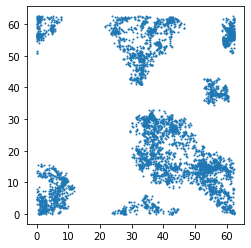

```python
plt.scatter(mf_3_5.x,mf_3_5.y,s=1)
plt.axes().set_aspect('equal')
```

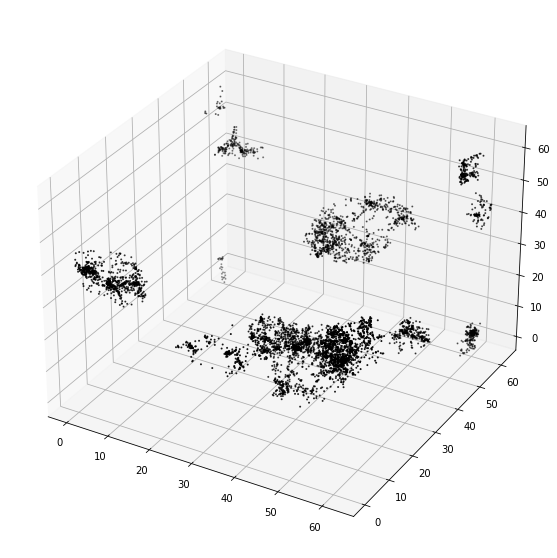

```python
fig = plt.figure(figsize=(10, 10))
ax = fig.add_subplot(111, projection='3d')
ax.scatter(mf_3_5.x,mf_3_5.y, mf_3_5.z,s=1,c='black');
```

## HF2

Find halo mass functions in overdensities at two different values.

```python
sql="""
   select '3 - 5' as lim,
       power(10, .1*(.5+floor(log10(h.np)/.1))) as mass,
       count(*) as num
  from millimil..MPAHalo h,
       millimil..MMField f
 where f.g5 between 3 and 5
   and f.snapnum=63
   and f.snapnum = h.snapnum
   and f.phkey = h.phkey
 group by 0*haloId, power(10, .1*(.5+floor(log10(h.np)/.1)))
union
 select '0.2 - 0.4' as lim,
        power(10, .1*(.5+floor(log10(h.np)/.1))) as mass,
        count(*) as num
  from millimil..MPAHalo h,
       millimil..MMField f
 where f.g5 between .2 and .4
   and f.snapnum=63
   and f.snapnum = h.snapnum
   and f.phkey = h.phkey
 group by 0*haloId+1, power(10, .1*(.5+floor(log10(h.np)/.1)))
order by lim,mass

"""
mfs=cj.executeQuery(sql,"millimil")
```

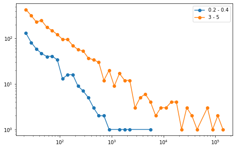

```python
groups=mfs.groupby(['lim'])
f,(ax)=plt.subplots(1,1,figsize=(8,5))
for i,group in groups:
    ax.plot(group.mass,group.num,'-o',label=i)
ax.set_xscale('log')
ax.set_yscale('log');
ax.legend();
```

## HF3

Assembly Bias ala Gao & White (2007).  
Find formation time dependency on background overdensities for halos in particular mass bin.

```python
sql="""
select zmax, avg(g5) as g5, stdev(g5) as g5err,
       avg(g10) as g10, stdev(g10) as g10err,
       count(*) as num
  from millimil..mmfield f,
       ( select des.haloId, des.np, des.phkey,max(PROG.redshift) as zmax
           from millimil..MPAHalo PROG,
                millimil..MPAHalo DES
          where DES.snapnum = 63
            and PROG.haloId between DES.haloId and DES.lastprogenitorId
            and prog.np >= des.np/2
            and des.np between 100 and 200
            and des.haloId = des.firsthaloinfofgroupid
          group by des.haloId, des.np ,des.phkey
       ) t
 where t.phkey = f.phkey
   and f.snapnum=63
group by zmax
"""
time_form=cj.executeQuery(sql,"millimil")
```

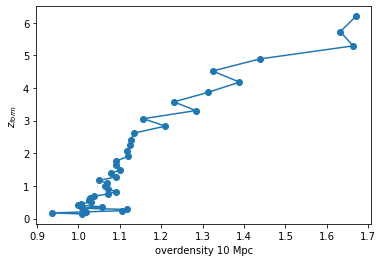

```python
plt.plot(time_form.g10,time_form.zmax,'-o')
plt.xlabel('overdensity 10 Mpc')
plt.ylabel('$z_{form}$');
```

## G1

Find galaxies at a given redshift (snapnum) within a certain part of the simulation volume (X,Y,Z)

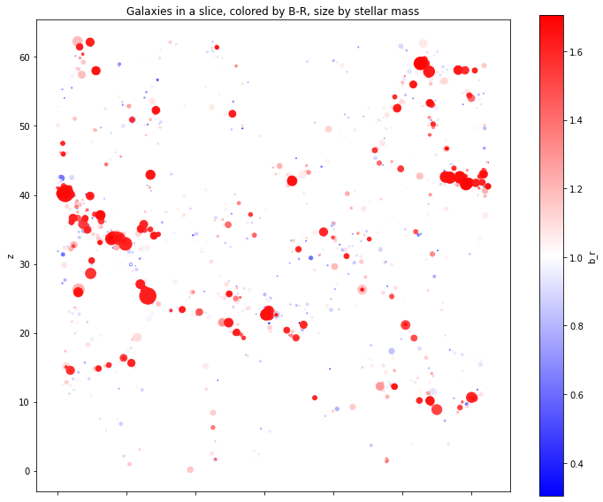

```python
ax=galaxies.plot.scatter('y','z',s='sm',c='b_r',colormap='bwr',figsize=(12,10));
ax.set_aspect('equal')
ax.set_title("Galaxies in a slice, colored by B-R, size by stellar mass");
```

[output not shown]

## G2

Find the whole progenitor tree, in depth-first order, of a galaxy identified by its galaxyId

```python
sql="""
select PROG.snapnum,prog.x,prog.y,prog.z,10.0*prog.stellarMass as sm
,      prog.mag_b-prog.mag_r as b_r
  from millimil..DeLucia2006a PROG,
       millimil..DeLucia2006a DES
 where DES.galaxyId = 1
   and PROG.galaxyId between DES.galaxyId and DES.lastprogenitorId
"""
galtree=cj.executeQuery(sql,"millimil")
```

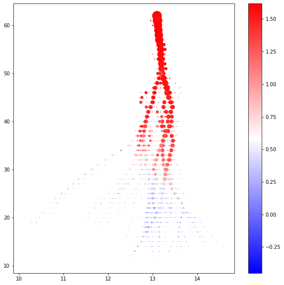

```python
fig,(ax)=plt.subplots(1,1,figsize=(10,10))
plt.scatter(galtree.y,galtree.snapnum,s=galtree.sm,c=galtree.b_r,cmap='bwr');
plt.colorbar();
```

## G3

Find the progenitors at a given redshift (snapnum) of all galaxies of brightness(magB) ≤ -20 at a later redshift (snapnum). The progenitors are limited in magnitude as well.

```python
sql="""
select DES.galaxyId as descendant_id,
       DES.stellarMass as descendant_mass,
       PROG.*
  from millimil..DeLucia2006a DES,
       millimil..DeLucia2006a PROG
 where DES.snapnum = 63
   and DES.mag_b < -20
   and PROG.galaxyId between DES.galaxyId and DES.lastprogenitorId
   and PROG.snapnum = 30
   and PROG.mag_b < -19
 order by DES.mag_b asc, PROG.mag_b asc
"""
```

## G4

Find all the galaxies of mag_b < -20 that have just had a major merger, defined by having at least two progenitors of mass ≥ 0.2*descendant mass.

```python
sql="""
select D.galaxyId,
       D.snapnum,
       D.mag_b as d_mag_b,
       D.sfr as d_sfr,
       P1.mag_b as p1_mag_b,
       P2.mag_b as p2_mag_b,
       D.stellarMass as d_mass,
       P1.stellarMass as p1_mass,
       P2.stellarMass as p2_mass
  from millimil..DeLucia2006a P1,
       millimil..DeLucia2006a P2,
       millimil..DeLucia2006a D
 where P1.SNAPNUM=P2.SNAPNUM
   and P1.galaxyId< P2.galaxyId
   and P1.descendantId = D.galaxyId
   and P2.descendantId = D.galaxyId
   and P1.stellarMass >= .2*D.stellarMass
   and P2.stellarMass >= .2*D.stellarMass
   and D.mag_b <-20"""
```

## G5

Find the luminosity function of galaxies at z=0.

```python
sql="""
select .2*(.5+floor(mag_b/.2)) as mag,
       count(*) as num
  from millimil..DeLucia2006a
 where mag_b < -10
   and snapnum=63
 group by .2*(.5+floor(mag_b/.2))
 order by mag
"""
gal_lf=cj.executeQuery(sql,"millimil")
```

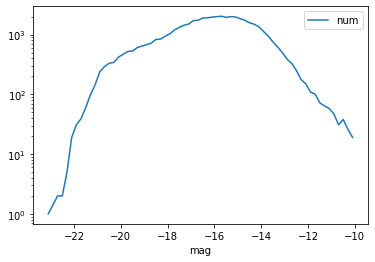

```python
ax=gal_lf.plot.line('mag','num')
ax.set_yscale('log');
```

## G6

Find the Tully-Fisher relation, Mag vs Vvir for galaxies with bulge/total mass ratio < 0.1.

```python
sql="""
select vVir, mag_b, mag_v, mag_i, mag_r, mag_k
,      mag_b-mag_r as b_r
  from millimil..DeLucia2006a
 where (bulgeMass < 0.1*stellarMass or bulgeMass is null)
   and snapnum = 41
"""
gal_tf=cj.executeQuery(sql,"millimil")
```

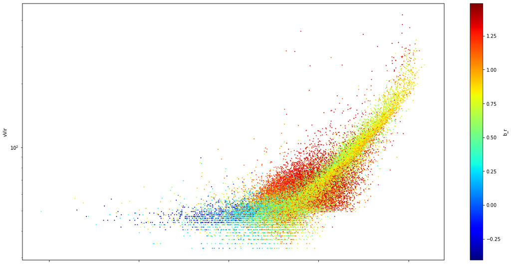

```python
ax=gal_tf.plot.scatter('mag_k','vVir',s=1,c='b_r',colormap='jet',figsize=(20,10))
ax.set_yscale('log');
ax.invert_xaxis()
```

## HG1

Find the conditional luminosity functions for galaxies in two ranges of halo masses

```python
sql="""
select '2000 - 3000' as lim,
       .2*(.5+floor(mag_b/.2)) as mag,
       count(*) as num
  from millimil..DeLucia2006a g,
       millimil..MPAHalo h
 where h.np between 2000 and 3000
   and h.snapnum=63
   and g.haloId = h.haloId
   and g.mag_b < 0
 group by 0*galaxyId, .2*(.5+floor(mag_b/.2))
union
select '200 - 300' as lim,
       .2*(.5+floor(mag_b/.2)) as mag,
       count(*) as num
  from millimil..DeLucia2006a g,
       millimil..MPAHalo h
 where h.np between 200 and 300
   and h.snapnum= 63
   and g.haloId = h.haloId
   and g.mag_b < 0
 group by 0*galaxyId+1, .2*(.5+floor(mag_b/.2))
order by lim,  mag
"""
gal_lfs=cj.executeQuery(sql,"millimil")
```

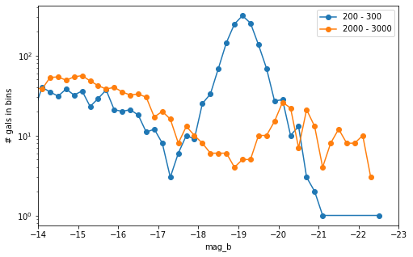

```python
groups=gal_lfs.groupby(['lim'])
f,(ax)=plt.subplots(1,1,figsize=(8,5))
for i,group in groups:
    ax.plot(group.mag,group.num,'-o',label=i)
ax.set_yscale('log');
ax.invert_xaxis()
ax.set_xlim(-14,-23)
ax.legend()
ax.set_xlabel("mag_b")
ax.set_ylabel("# gals in bins");
```

## HG2

Find average galaxy properties as function of halo mass.

```python
sql="""
select power(10.0, .1*(.5+floor(log(cast(g.np as real))/.1))) as halo_np,
       avg(g.stellarMass) as stars_avg,
       max(g.stellarMass) as stars_max,
       avg(g.bulgeMass) as bulge_avg,
       max(g.bulgeMass) as bulge_max,
       avg(g.mag_b-g.mag_v) as color_avg
  from millimil..DeLucia2006a g
 where g.snapnum= 63
   and g.mag_b < 0
 group by floor(log(cast(g.np as real))/.1)
 order by 1
"""
gal_props=cj.executeQuery(sql,"millimil")
```

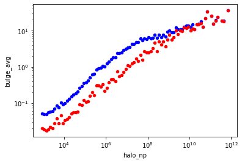

```python
ax=gal_props.plot.scatter('halo_np','stars_avg',c='blue')
ax=gal_props.plot.scatter('halo_np','bulge_avg',ax=ax,c='red')
ax.set_xscale('log')
ax.set_yscale('log');
```